# hw00-donghan2

Liu, Donghan, Donghan2

2018-01-19

# Solution

## Exercise 1

### Exercise 1a

```r
#install.packages("faraway")
library(faraway)
data(diabetes)
```

### Exercise 1b

```r
#install.packages("tibble")
library(tibble)
diabete = as_tibble(diabetes)
diabete
```

```
## # A tibble: 403 x 19
##       id  chol stab.glu   hdl ratio glyhb location     age gender height
##  * <int> <int>    <int> <int> <dbl> <dbl> <fct>      <int> <fct>   <int>
##  1  1000   203       82    56  3.60  4.31 Buckingham    46 female     62
##  2  1001   165       97    24  6.90  4.44 Buckingham    29 female     64
##  3  1002   228       92    37  6.20  4.64 Buckingham    58 female     61
##  4  1003    78       93    12  6.50  4.63 Buckingham    67 male       67
##  5  1005   249       90    28  8.90  7.72 Buckingham    64 male       68
##  6  1008   248       94    69  3.60  4.81 Buckingham    34 male       71
##  7  1011   195       92    41  4.80  4.84 Buckingham    30 male       69
##  8  1015   227       75    44  5.20  3.94 Buckingham    37 male       59
##  9  1016   177       87    49  3.60  4.84 Buckingham    45 male       69
## 10  1022   263       89    40  6.60  5.78 Buckingham    55 female     63
## # ... with 393 more rows, and 9 more variables: weight <int>, frame <fct>,
## #   bp.1s <int>, bp.1d <int>, bp.2s <int>, bp.2d <int>, waist <int>,
## #   hip <int>, time.ppn <int>
```

```r
?diabetes
```

```
## starting httpd help server ...
```

```
##  done
```

As the table shows that there are 403 observations and 19 variables. The individuals are 403 African Americans in Virginia, as shown in the datasets help.

### Exercise 1c

```r
mean(diabete$hdl)
```

```
## [1] NA
```

```r
mean(diabete$hdl,na.rm = TRUE)
```

```
## [1] 50.44527
```

Since the dataset contains nan value(mean = NA), we have to remove them before doing calculations.

### Exercise 1d

```r
mean(diabete$hdl[diabete$gender == 'female'])
```

```
## [1] 52.11111
```

### Exercise 1e

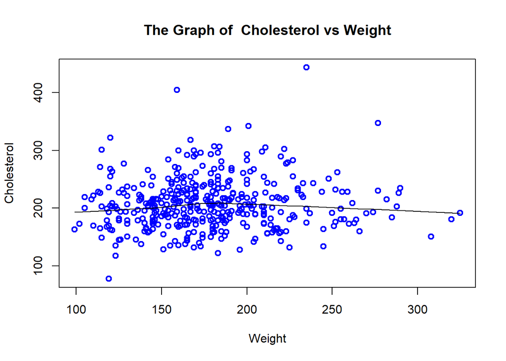

```r
lines(scatter.smooth(diabete$weight,diabete$chol, col="blue", lty=1, lwd=2,xlab = 'Weight',ylab = 'Cholesterol',main = 'The Graph of  Cholesterol vs Weight'))
```

As seen the trend line in the graph, it is very flat and only small curve in the plot, so the relationship is not obvious.

### Exercise 1f

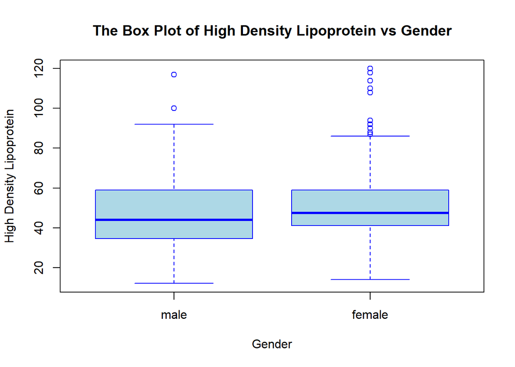

```r
boxplot(hdl~gender,data = diabete,col = 'lightblue',xlab = 'Gender',ylab = 'High Density Lipoprotein',main = 'The Box Plot of High Density Lipoprotein vs Gender',border = 'blue')
```

Regarding the variation, the female’s is smaller than the male’s, thus, there might be some slight difference between female and male with respect in High Density Lipooprotein.

## Exercise 2

### Exercise 2a

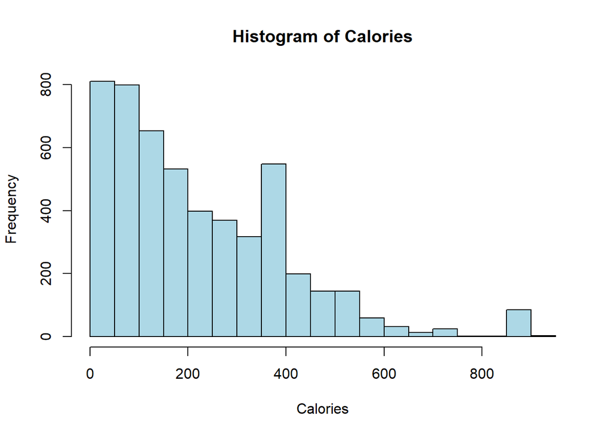

```r
nutri = read.csv("c:/Users/Hans/Desktop/nutrition.csv")
hist(nutri$Calories,col = 'lightblue',main = 'Histogram of Calories',xlab = 'Calories')
```

### Exercise 2b

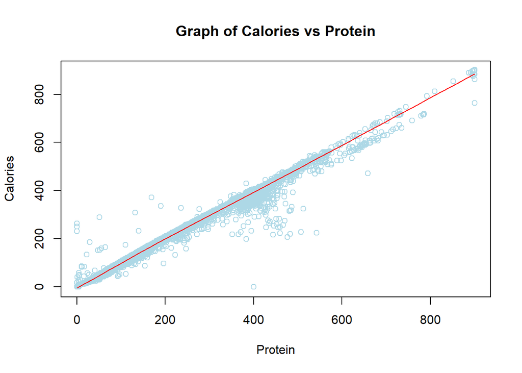

```r
scatter.smooth(x = 4 * nutri$Protein + 4 * nutri$Carbs + 9 * nutri$Fat + 2 * nutri$Fiber,y = nutri$Calories,col = 'lightblue',lpars = list(col = 'red'),main = 'Graph of Calories vs Protein',xlab = 'Protein',ylab = 'Calories')
```

Even though the red line seems like a staight line, but there are unusual phenomenon appears, which was indicted above. Plus, from the formula regarding the food component to generate calories, ethanol, organic acids, and polyols are not considered. Also, the inaccurate data might cause the same issue.

## Exercise 3

### Exercise 3a

```r
a = 1:10
b = 10:1
c = rep(1, times = 10)
d = 2 ^ (1:10)

sum_of_squares = function(x){
  y = 0
  for (i in x){
    y = y + i^2
  }
  return(y)
}
sum_of_squares(x = a)
```

```
## [1] 385
```

```r
sum_of_squares(x = c(c, d))
```

```
## [1] 1398110
```

### Exercise 3b

```r
rms_diff = function(x,y){
  return(sqrt((1/length(x))*sum((x-y)^2)))
}
rms_diff(x = a, y = b)
```

```
## [1] 5.744563
```

```r
rms_diff(x = d, y = c)
```

```
## [1] 373.3655
```

```r
rms_diff(x = d, y = 1)
```

```
## [1] 373.3655
```

```r
rms_diff(x = a, y = 0) ^ 2 * length(a)
```

```
## [1] 385
```